# Hayward, George - IAS Code - May 11, 2024_ anon

Additionally, there are other ways to feature prune. I can do it on correlation scores, though generally, I like to use a gradient boosted tree, which does not mind colinearity as much as a logistic regression will.

I like this pruning technique because when we look at p-values and coefficients as a way to prune, it's a way for to take into account one variable's lift considering all the other inter-related and inter-acting variables, so this p-value/coefficient method (here I use the lowest absolute coefficient to 'the next feature off the island,' so to speak), lets us to whittle down the model without losing the big picture.

Logistic regressions are a bit more interpretable than XGBoost, which can be a bit of a black box. So when whittling down the features, it helps to see the impact of each one as we go. Now it is possible to get an idea of XGBoost with SHAP values, but that's outside the scope for now. When showing an executive, a logistic regression is best, I think, and when modeling a XGBoost model has more power, though we lose some interpretability.

We also do want to apply common sense. A one year contract, and a two year contract are bins for tenure, so we may consider some of those features 'cheating,' and we'd remove them to better understand the data.

In practice I prefer to run models such as this on the IQR (interquartile range), unless we are dealing with data that relies heavily on the impact of outliers, such as insurance datasets.

Table of Contents

Part 4. Recommendations

- Given all the insight above, I recommend investing more in **customer retention** than in new business prospecting. I'll try to illustrate this idea below with a few of the above graphs, reproduced.

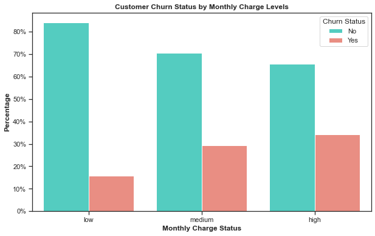

```python
hds.plt.figure(figsize=(10, 6))
barplot = hds.sns.barplot(data=question2_part2, x='monthly_charge_status',\
                      y='percentage_per_monthly_charge_status', hue='churn_status',\
                      palette={'No': 'turquoise', 'Yes': 'salmon'})
PercentFormatter = hds.matplotlib.ticker.PercentFormatter
hds.plt.gca().yaxis.set_major_formatter(PercentFormatter(1))
hds.plt.title('Customer Churn Status by Monthly Charge Levels', fontweight="bold")
hds.plt.xlabel('Monthly Charge Status', fontweight="bold")
hds.plt.ylabel('Percentage', fontweight="bold")
hds.plt.legend(title='Churn Status')
hds.plt.savefig('churn_status_by_monthly_charge_levels.png',dpi=300, bbox_inches='tight')
hds.plt.show()
```

- As you can see, the more we charge monthly, the more churn we get, and the less customer retention we have.

```
Percentile 1: 19.2
Percentile 25: 35.62
Percentile 50: 70.35
Percentile 75: 89.88
Percentile 90: 102.65
Percentile 95: 107.44
Percentile 97.0: 110.1
Percentile 98.0: 111.58
Percentile 99.0: 114.74
Percentile 99.7: 116.45
Percentile 99.9: 117.6
Percentile 99.99: 118.68
```

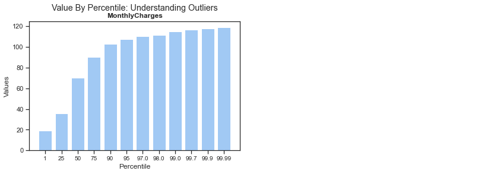

```python
HaywardGeneral.hayward_percentiler_Python(ias_df_wrangled, "MonthlyCharges")
```

- But when we look at the percentiles, we see that the difference between p25 and p50, is way bigger than betweent p50 and p75. If we could just get that p75 group closer to the p50 group, we'd probably hold a lot more customers. This is also borne out below.

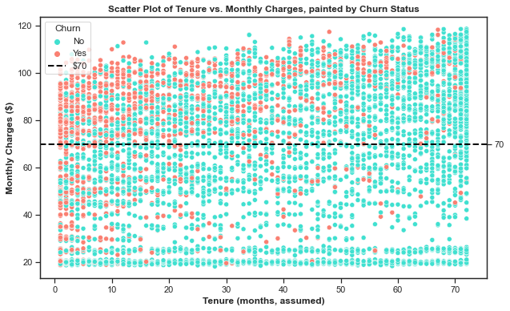

```python
Line2D = hds.matplotlib.lines.Line2D
hds.plt.figure(figsize=(10, 6))
ax = hds.sns.scatterplot(data=ias_df_wrangled, x='tenure', y='MonthlyCharges', hue='Churn',\
                palette={'Yes': 'salmon', 'No': 'turquoise'})
hds.plt.title('Scatter Plot of Tenure vs. Monthly Charges, painted by Churn Status', fontweight="bold")
hds.plt.xlabel('Tenure (months, assumed)', fontweight="bold")
hds.plt.ylabel('Monthly Charges ($)', fontweight="bold")

line = Line2D([0], [0], label='$70', color='black', linestyle='--', linewidth=2)
handles, labels = hds.plt.gca().get_legend_handles_labels()
handles.append(line)
hds.plt.legend(handles=handles, title='Churn')

hds.plt.axhline(y=70, color='black', linestyle='--', linewidth=2)

"""
#for putting the extra 70 tick on the left
current_ticks = hds.plt.gca().get_yticks()
# make sure 70 is in the clicks, and we don't want to duplicate it
if 70 not in current_ticks:
    new_ticks = hds.np.append(current_ticks, 70) #include 70
    new_ticks = sorted(new_ticks) #sort em
    hds.plt.yticks(new_ticks)  #set the new tick
"""

# for putting the extra 70 tick on the RIGHT
# 2nd axis
ax_right = ax.twinx()
# set limits of rightmost y-axis to include 70
ax_right.set_ylim(ax.get_ylim())  # ajust range of 2nd axis to fit the dat
# set ticks on rightmost yaxis
ax_right.set_yticks([70])
# explictly label the y axis
ax_right.set_yticklabels(['70'])

hds.plt.savefig('Tenure_vs_MonthlyCharge_colored_by_Churn.png',dpi=300, bbox_inches='tight')
hds.plt.show()
```

- As you can see above with my dotted black horizontal line at **\$70**, most of the churns happen with the higher prices, and earlier on in tenure. I recommend offering customers a sale or promotion at some point in their first 10 months to get them as close to **\$70** a month as possible. Once this sale/promotion launches, we will A/B test the customer retention, and if we see a true effect (or at least a strong correlation) from the sale/promotion, we will then adjust down the dollar amount of the sale/promotion to match the business break even point. Meaning: we'll adjust this promotion/sale offering to a price level so that the money we lose in the month-to-month charges, we ultimately get recoup in the lifetime value of the customer that we didn't lose, and in savings from the customer acquisition costs we no longer have.

Table of Contents

[figure not shown]

#### The Lord Always Delivers!